# Performance Analysis

### by: Abdullah Raslan

```python
# importing needed libraries
import pandas as pd
import numpy as np
import datetime as dt
import matplotlib.pyplot as plt
import seaborn as sns
sns.set_theme(style='darkgrid')
pd.options.display.float_format = '{:,.3f}'.format
```

## Data Gathering

> Getting the data out of database imported from Excel file:

```python
df = pd.read_excel('Case Study.xlsx')
df.head()
```

|  | Team | Item ID | Stage 1 date | Stage 2 STATUS | Stage 2 DATE | Stage 3 DATE | Stage 4 DATE | Stage 4 STATUS | Process Type |
| --- | --- | --- | --- | --- | --- | --- | --- | --- | --- |
| 0 | Team 1 | 8973715986 | 2022-06-19 | Done | 2022-06-21 | 2022-06-19 | 2022-06-21 | Done | Automatic |
| 1 | Team 1 | 9033264072 | 2022-06-19 | Done | 2022-06-26 | 2022-06-26 | 2022-06-28 | Done | Automatic |
| 2 | Team 1 | 9033264229 | 2022-06-19 | Done | 2022-06-26 | 2022-06-26 | 2022-06-28 | Done | Automatic |
| 3 | Team 1 | 9033265084 | 2022-06-19 | Done | 2022-06-26 | 2022-06-26 | 2022-06-28 | Done | Automatic |
| 4 | Team 1 | 9033265189 | 2022-06-19 | Done | 2022-06-26 | 2022-06-26 | 2022-06-28 | Done | Automatic |

## Data Exploring

> First step of doing performance analysis starts by exploring data and its features:

```python
# Getting to know the size of data (records (rows) & features (columns))
shape = df.shape
print(f"This data contains {shape[1]} features and {shape[0]} records.")
```

```
This data contains 9 features and 332246 records.
```

Exploring unique values of each feature:

```python
# Names of the teams in the dataset
df['Team'].unique()
```

```
array(['Team 1', 'Team 3', 'Team 4', 'Team 2'], dtype=object)
```

```python
# Unique items in the dataset
item_count = df['Item ID'].nunique()
print(f'This dataset contains {item_count} item types')
```

```
This dataset contains 149846 item types
```

```python
#Status types in the dataset
(df['Stage 2 STATUS'].unique(),
df['Stage 4 STATUS'].unique())
```

```
(array(['Done', 'Hold', 'Reject'], dtype=object),
 array(['Done', 'Hold', 'Not Done', 'Reject'], dtype=object))
```

```python
#Process types in the dataset
df['Process Type'].unique()
```

```
array(['Automatic', 'Manual', 'Semi Automatic'], dtype=object)
```

Based on screening data above we need to change the data types for multiple columns to be able to conduct our analysis.

## Data Cleaning & Wrangling

Based on analysis above, the following points need to be adjusted & wrangled:  
1- Columns' names to be adjusted for easiness of analysis.  
2- `Item ID` data type to be changed from number to text.  
3- [`Team`, `Stage 2 STATUS`, `Stage 4 STATUS`, `Process Type`] to be converted from object to categorical data type.  
4- To add a new column to calculate the duration from Stage 1 till Stage 4  
5- Explore what stages that work in parallel and what stages are depending on others.  
6- If there was independices, more durations needs to be added to breakdown the performance of each team.

```python
df_clean = df.copy()
```

#### 1- Changing columns' names:

Change the column names to be: (team, item_id, stage1_date, stage2_status, stage2_date, stage3_date, stage4_date, stage4_status, process_type)

```python
column_names = ['team', 'item_id', 'stage1_date', 'stage2_status', 'stage2_date', 'stage3_date', 'stage4_date', 'stage4_status', 'process_type']
df_clean.columns = column_names
df_clean.head()
```

|  | team | item_id | stage1_date | stage2_status | stage2_date | stage3_date | stage4_date | stage4_status | process_type |
| --- | --- | --- | --- | --- | --- | --- | --- | --- | --- |
| 0 | Team 1 | 8973715986 | 2022-06-19 | Done | 2022-06-21 | 2022-06-19 | 2022-06-21 | Done | Automatic |
| 1 | Team 1 | 9033264072 | 2022-06-19 | Done | 2022-06-26 | 2022-06-26 | 2022-06-28 | Done | Automatic |
| 2 | Team 1 | 9033264229 | 2022-06-19 | Done | 2022-06-26 | 2022-06-26 | 2022-06-28 | Done | Automatic |
| 3 | Team 1 | 9033265084 | 2022-06-19 | Done | 2022-06-26 | 2022-06-26 | 2022-06-28 | Done | Automatic |
| 4 | Team 1 | 9033265189 | 2022-06-19 | Done | 2022-06-26 | 2022-06-26 | 2022-06-28 | Done | Automatic |

#### 2- Convert `item_id` data type:

Convert `item_id` column from integer into a string.

```python
df_clean['item_id'] = df_clean['item_id'].astype('str')
```

#### 3- Convert [`team`, `stage2_status`, `stage4_status`, `process_type`] data types:

Convert the mentioned columns from string into a categorical data type.

```python
df_clean['team'] = df_clean.team.astype('category')
df_clean['stage2_status'] = df_clean.stage2_status.astype('category')
df_clean['stage4_status'] = df_clean.stage4_status.astype('category')
df_clean['process_type'] = df_clean.process_type.astype('category')
```

```python
df_clean.dtypes
```

```
team                   category
item_id                  object
stage1_date      datetime64[ns]
stage2_status          category
stage2_date      datetime64[ns]
stage3_date      datetime64[ns]
stage4_date      datetime64[ns]
stage4_status          category
process_type           category
dtype: object
```

> Now we are ready with all data types to start wrangling the data

#### 4- Adding new column to calculate the duration of the task

```python
def duration(x, y, condition):
    task_duration = []
    for i in range(x.shape[0]):
        if condition[i]:
            task_duration.append(y[i] - x[i])
        else:
            task_duration[i].append("-")
    return task_duration
```

```python
df_clean['task_duration'] = duration(df_clean['stage1_date'],df_clean['stage4_date'],df_clean['stage4_status'])
```

```python
df_clean['task_duration'] = df_clean['task_duration'].dt.days
```

#### 5- Explore Stages Dependency Rules:

It was not mentioned that all stages are depending on each other which means that each stage doesn't need to be finished before the next stage starts. To assure this assumption I will do a simple checker to validate dependency:

#### 5.1- Checking if Stage 2 is depending on Stage 1:

```python
np.min(duration(df_clean['stage1_date'],df_clean['stage2_date'],df_clean['stage2_status']))
```

```
Timedelta('0 days 00:00:00')
```

> Since there is no negative duration that means all teams have started stage 2 after stage 1

#### 5.2- Checking if Stage 3 is depending on Stage 2:

```python
np.min(duration(df_clean['stage2_date'],df_clean['stage3_date'],df_clean['stage2_status']))
```

```
Timedelta('-12 days +00:00:00')
```

> Clearly we can notice negative duration which means that at least one team has finished stage 3 before stage 2 which means Stage 3 is not dependent on Stage 2

#### 5.3- Checking if Stage 4 is depending on Stage 3:

```python
stage4_filtered = df_clean.copy()
stage4_filtered = stage4_filtered.dropna()
stage4_filtered = stage4_filtered.reset_index(drop=True)
```

```python
np.min(duration(stage4_filtered['stage3_date'],stage4_filtered['stage4_date'],stage4_filtered['stage2_status']))
```

```
Timedelta('0 days 00:00:00')
```

> Since there is no negative duration that means all teams have started stage 4 after stage 3

#### 6. Grouped Task duration:

```python
# Duration for Stage_1to2
df_clean['s1s2_duration'] = duration(df_clean['stage1_date'],df_clean['stage2_date'],df_clean['stage2_status'])
```

```python
df_clean.describe()
```

[output not shown]

In order to evaluate performance we must add End-2-End duration for each task.

```python
df_clean['e2e_duration'] = df_clean[['s1s2_duration','s3s4_duration','task_duration']].max(axis=1)
df_clean.head()
```

|  | team | item_id | stage1_date | stage2_status | stage2_date | stage3_date | stage4_date | stage4_status | process_type | task_duration | s1s2_duration | s3s4_duration | e2e_duration |
| --- | --- | --- | --- | --- | --- | --- | --- | --- | --- | --- | --- | --- | --- |
| 0 | Team 1 | 8973715986 | 2022-06-19 | Done | 2022-06-21 | 2022-06-19 | 2022-06-21 | Done | Automatic | 2.000 | 2 | 2.000 | 2.000 |
| 1 | Team 1 | 9033264072 | 2022-06-19 | Done | 2022-06-26 | 2022-06-26 | 2022-06-28 | Done | Automatic | 9.000 | 7 | 2.000 | 9.000 |
| 2 | Team 1 | 9033264229 | 2022-06-19 | Done | 2022-06-26 | 2022-06-26 | 2022-06-28 | Done | Automatic | 9.000 | 7 | 2.000 | 9.000 |
| 3 | Team 1 | 9033265084 | 2022-06-19 | Done | 2022-06-26 | 2022-06-26 | 2022-06-28 | Done | Automatic | 9.000 | 7 | 2.000 | 9.000 |
| 4 | Team 1 | 9033265189 | 2022-06-19 | Done | 2022-06-26 | 2022-06-26 | 2022-06-28 | Done | Automatic | 9.000 | 7 | 2.000 | 9.000 |

> Now we have a full set of durations to be assessed

## Data Analysis:

### A- Exploratory Visualization:

#### 1- Task disribution among teams:

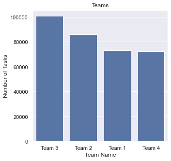

```python
# Exploring teams task distribution
plt.figure(figsize=(5,5))
base_color = sns.color_palette()[0]
plot_order = df_clean['team'].value_counts().index
sns.countplot(data = df_clean, x='team', color = base_color, order= plot_order)
plt.title('Teams')
plt.ylabel('Number of Tasks', fontsize=12)
plt.xlabel('Team Name', fontsize=12)
plt.show()
```

> Each team has a fair share of tasks assigned to them

#### 2- Most used process type:

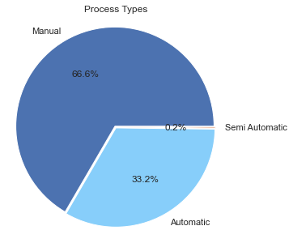

```python
plt.figure(figsize=(5,5))
colors = [sns.color_palette()[0], 'lightskyblue', sns.color_palette()[1]]
explode = (0.01, 0.01, 0.01)
plt.pie(show_pie, labels=['Manual', 'Automatic', 'Semi Automatic'], autopct='%1.1f%%', explode=explode, colors= colors);
plt.axis('square')
plt.title('Process Types')

plt.show()
```

> Most tasks are Manual. And only very few of tasks are Semi Automatic

#### 3- Checking on Stage 2 & 4 Status:

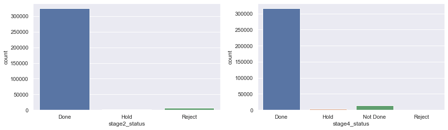

```python
plt.figure(figsize = [15, 4])
base_color = sns.color_palette()[0]


plt.subplot(1, 2, 1)
sns.countplot(data=df_clean, x='stage2_status');


plt.subplot(1, 2, 2)
sns.countplot(data=df_clean, x='stage4_status');
```

> Most tasks' staus is **Done**, for the sake of this analysis we will only focus on The performance of the tasks that have been done.

#### 4- Top 100 Items Distribuiton:

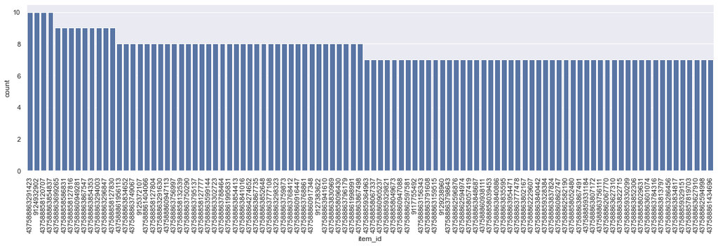

```python
plt.figure(figsize = [20, 5])
base_color = sns.color_palette()[0]
sns.countplot(data=top_items_df, x='item_id', order=items.index, color=base_color);
plt.xticks(rotation=90);
```

> Based on distribution above, we can't rely on focusing only on top 10 items because their contribution is not significant.?

#### 5- Task Duration Distributions:

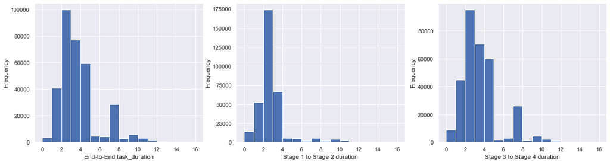

```python
binsize = 1
bins = np.arange(0, df_clean['e2e_duration'].max()+binsize, binsize)
plt.figure(figsize=[20, 5])

plt.subplot(1, 3, 1)
plt.hist(data = df_clean, x = 'e2e_duration' ,bins=bins)
plt.xlabel('End-to-End task_duration')
plt.ylabel('Frequency')

plt.subplot(1, 3, 2)
plt.hist(data = df_clean, x = 's1s2_duration' ,bins=bins)
plt.xlabel('Stage 1 to Stage 2 duration')
plt.ylabel('Frequency')

plt.subplot(1, 3, 3)
plt.hist(data = df_clean, x = 's3s4_duration' ,bins=bins)
plt.xlabel('Stage 3 to Stage 4 duration')
plt.ylabel('Frequency')

plt.show()
```

#### 6-Task Duration Distributions per team

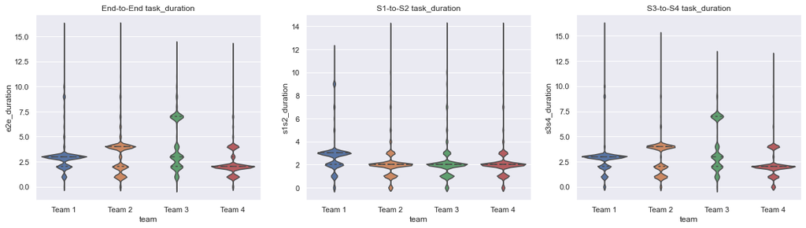

```python
plt.figure(figsize=[20, 5])

plt.subplot(1, 3, 1)
sns.violinplot(data=df_clean, x='team', y='e2e_duration', inner = 'quartile');
plt.title('End-to-End task_duration')

plt.subplot(1, 3, 2)
sns.violinplot(data=df_clean, x='team', y='s1s2_duration', inner = 'quartile');
plt.title('S1-to-S2 task_duration')

plt.subplot(1, 3, 3)
sns.violinplot(data=df_clean, x='team', y='s3s4_duration', inner = 'quartile');
plt.title('S3-to-S4 task_duration');
```

> We also have to observe closely Team 3 in specific when analyzing performance of S3-to-S4 success rate

#### 7- Process Types Usage by Teams:

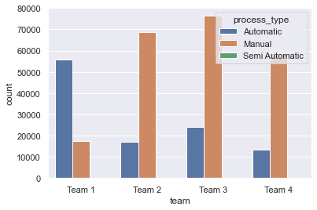

```python
sns.countplot(x = "team", hue = "process_type", data = df_clean)
plt.show()
```

> Most task assigned for Team 1 are Automatic. While other teams mainly use Manual process type.

### B- Feature engineering:

#### 1- Creating Success rate KPI to evaluate performance:

```python
completion_target = 7
df_clean = df_clean.assign(s1s2_success = lambda x: x['s1s2_duration'].apply(lambda y: 1 if y <= completion_target  else 0))
```

```python
df_clean = df_clean.assign(s3s4_success = lambda x: x['s3s4_duration'].apply(lambda y: 1 if y <= completion_target  else 0))
```

```python
df_clean = df_clean.assign(e2e_success = lambda x: x['e2e_duration'].apply(lambda y: 1 if y <= completion_target  else 0))
df_clean.head()
```

|  | team | item_id | stage1_date | stage2_status | stage2_date | stage3_date | stage4_date | stage4_status | process_type | task_duration | s1s2_duration | s3s4_duration | e2e_duration | s1s2_success | s3s4_success | e2e_success |
| --- | --- | --- | --- | --- | --- | --- | --- | --- | --- | --- | --- | --- | --- | --- | --- | --- |
| 0 | Team 1 | 8973715986 | 2022-06-19 | Done | 2022-06-21 | 2022-06-19 | 2022-06-21 | Done | Automatic | 2.000 | 2 | 2.000 | 2.000 | 1 | 1 | 1 |
| 1 | Team 1 | 9033264072 | 2022-06-19 | Done | 2022-06-26 | 2022-06-26 | 2022-06-28 | Done | Automatic | 9.000 | 7 | 2.000 | 9.000 | 1 | 1 | 0 |
| 2 | Team 1 | 9033264229 | 2022-06-19 | Done | 2022-06-26 | 2022-06-26 | 2022-06-28 | Done | Automatic | 9.000 | 7 | 2.000 | 9.000 | 1 | 1 | 0 |
| 3 | Team 1 | 9033265084 | 2022-06-19 | Done | 2022-06-26 | 2022-06-26 | 2022-06-28 | Done | Automatic | 9.000 | 7 | 2.000 | 9.000 | 1 | 1 | 0 |
| 4 | Team 1 | 9033265189 | 2022-06-19 | Done | 2022-06-26 | 2022-06-26 | 2022-06-28 | Done | Automatic | 9.000 | 7 | 2.000 | 9.000 | 1 | 1 | 0 |

#### 1.1- Analyze Performance per Team

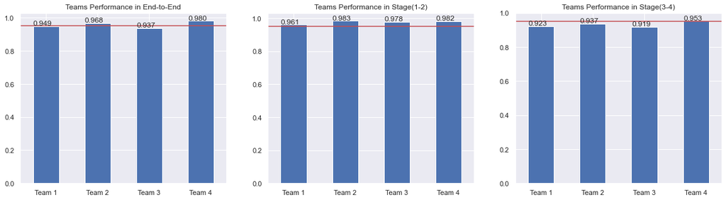

```python
plt.figure(figsize = [20, 5])
plt.subplot(1, 3, 1)
ax = team_e2e_performance.plot.bar(rot=0, title="Teams Performance in End-to-End");

plt.subplot(1, 3, 2)
ay = team_s1s2_performance.plot.bar(rot=0, title="Teams Performance in Stage(1-2)");

plt.subplot(1, 3, 3)
az = team_s3s4_performance.plot.bar(rot=0, title="Teams Performance in Stage(3-4)");

# Add annotation to bars
for i in [ax, ay, az]:
    i.axhline(0.95, c='r')
    for p in i.patches:
        i.annotate("{:.3f}".format(p.get_height()), (p.get_x() * 1.005, p.get_height() * 1.005))

plt.show();
```

> By seeing the fiqures above we can see how each team is performing at each stage.

#### 1.2- Analyze Performance Per Process Type

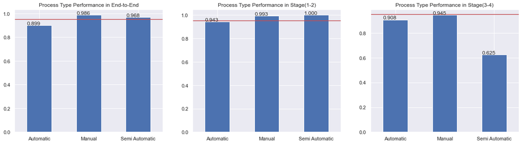

```python
plt.figure(figsize = [20, 5])
plt.subplot(1, 3, 1)
ax = process_type_e2e_performance.plot.bar(rot=0, title="Process Type Performance in End-to-End");

plt.subplot(1, 3, 2)
ay = process_type_s1s2_performance.plot.bar(rot=0, title="Process Type Performance in Stage(1-2)");

plt.subplot(1, 3, 3)
az = process_type_s3s4_performance.plot.bar(rot=0, title="Process Type Performance in Stage(3-4)");
# Add annotation to bars
for i in [ax, ay, az]:
    i.axhline(0.95, c='r')
    for p in i.patches:
        i.annotate("{:.3f}".format(p.get_height()), (p.get_x() * 1.005, p.get_height() * 1.005))
plt.show();
```

#### 1.3- Analyze Performance Per Team and Process Type

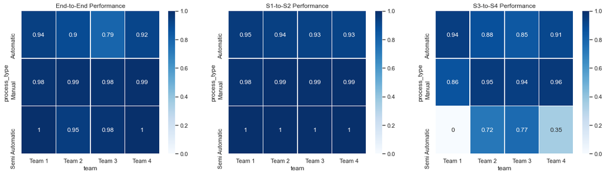

```python
plt.figure(figsize = [20, 5])

plt.subplot(1, 3, 1)
sns.heatmap(matrix_e2e_performance, annot = True, vmin=0, vmax=1, linewidths=.5, cmap="Blues");
plt.title('End-to-End Performance')

plt.subplot(1, 3, 2)
sns.heatmap(matrix_s1s2_performance, annot = True, vmin=0, vmax=1, linewidths=.5, cmap="Blues");
plt.title('S1-to-S2 Performance')

plt.subplot(1, 3, 3)
sns.heatmap(matrix_s3s4_performance, annot = True, vmin=0, vmax=1, linewidths=.5, cmap="Blues");
plt.title('S3-to-S4 Performance');
```